# R Notebook

#Installing and loading necessary Package: Loading the ‘readr’ package for data reading functions, ‘dplyr’ for data manipulation, ‘ggplot2’ for data visualization.

```r
install.packages("ggplot2")
```

```
Error in install.packages : Updating loaded packages
```

```r
install.packages("caret")
```

```
Error in install.packages : Updating loaded packages
```

```r
library(readr)
library(dplyr)
library(ggplot2)
library(gmodels)
library(package = "lsr")
library(caret)
```

```r
diabetes_data <- read_csv("diabetes_prediction_dataset.csv")
```

Dataset was imported and labelled as diabetes_data.The data has 9 variables with 100000 observations.

#Displaying the initial rows of the dataframe to check its structure

```r
head(diabetes_data)
```

| gender | age | hypertension | heart_disease | smoking_history | bmi | HbA1c_level | blood_glucose_level | diabetes |
| --- | --- | --- | --- | --- | --- | --- | --- | --- |
| Female | 80 | 0 | 1 | never | 25.19 | 6.6 | 140 | 0 |
| Female | 54 | 0 | 0 | No Info | 27.32 | 6.6 | 80 | 0 |
| Male | 28 | 0 | 0 | never | 27.32 | 5.7 | 158 | 0 |
| Female | 36 | 0 | 0 | current | 23.45 | 5.0 | 155 | 0 |
| Male | 76 | 1 | 1 | current | 20.14 | 4.8 | 155 | 0 |
| Female | 20 | 0 | 0 | never | 27.32 | 6.6 | 85 | 0 |

The initial rows of the dataset is displayed using head() function.

#Conduct a descriptive statistical summary of the data

```r
summary(diabetes_data)
```

```
    gender               age         hypertension     heart_disease     smoking_history
 Length:100000      Min.   : 0.08   Min.   :0.00000   Min.   :0.00000   Length:100000
 Class :character   1st Qu.:24.00   1st Qu.:0.00000   1st Qu.:0.00000   Class :character
 Mode  :character   Median :43.00   Median :0.00000   Median :0.00000   Mode  :character
                    Mean   :41.89   Mean   :0.07485   Mean   :0.03942
                    3rd Qu.:60.00   3rd Qu.:0.00000   3rd Qu.:0.00000
                    Max.   :80.00   Max.   :1.00000   Max.   :1.00000
      bmi         HbA1c_level    blood_glucose_level    diabetes
 Min.   :10.01   Min.   :3.500   Min.   : 80.0       Min.   :0.000
 1st Qu.:23.63   1st Qu.:4.800   1st Qu.:100.0       1st Qu.:0.000
 Median :27.32   Median :5.800   Median :140.0       Median :0.000
 Mean   :27.32   Mean   :5.528   Mean   :138.1       Mean   :0.085
 3rd Qu.:29.58   3rd Qu.:6.200   3rd Qu.:159.0       3rd Qu.:0.000
 Max.   :95.69   Max.   :9.000   Max.   :300.0       Max.   :1.000
```

Summary of diabetes data is displayed using summary() function.

#Checking the missing values

```r
sum(is.na(diabetes_data))
```

```
[1] 0
```

The dataset does not contain any missing values.

Structure of the diabetes data

```r
str(diabetes_data)
```

```
spc_tbl_ [100,000 × 9] (S3: spec_tbl_df/tbl_df/tbl/data.frame)
 $ gender             : chr [1:100000] "Female" "Female" "Male" "Female" ...
 $ age                : num [1:100000] 80 54 28 36 76 20 44 79 42 32 ...
 $ hypertension       : num [1:100000] 0 0 0 0 1 0 0 0 0 0 ...
 $ heart_disease      : num [1:100000] 1 0 0 0 1 0 0 0 0 0 ...
 $ smoking_history    : chr [1:100000] "never" "No Info" "never" "current" ...
 $ bmi                : num [1:100000] 25.2 27.3 27.3 23.4 20.1 ...
 $ HbA1c_level        : num [1:100000] 6.6 6.6 5.7 5 4.8 6.6 6.5 5.7 4.8 5 ...
 $ blood_glucose_level: num [1:100000] 140 80 158 155 155 85 200 85 145 100 ...
 $ diabetes           : num [1:100000] 0 0 0 0 0 0 1 0 0 0 ...
 - attr(*, "spec")=
  .. cols(
  ..   gender = col_character(),
  ..   age = col_double(),
  ..   hypertension = col_double(),
  ..   heart_disease = col_double(),
  ..   smoking_history = col_character(),
  ..   bmi = col_double(),
  ..   HbA1c_level = col_double(),
  ..   blood_glucose_level = col_double(),
  ..   diabetes = col_double()
  .. )
 - attr(*, "problems")=<externalptr>
```

Categorical variables are converted into factor using as.factor()

```r
diabetes_data$gender <- as.factor(diabetes_data$gender)
diabetes_data$hypertension <- as.factor(diabetes_data$hypertension)
diabetes_data$heart_disease <- as.factor(diabetes_data$heart_disease)
diabetes_data$smoking_history <- as.factor(diabetes_data$smoking_history)
```

Structure od the data after converting into factor

```r
str(diabetes_data)
```

```
spc_tbl_ [100,000 × 9] (S3: spec_tbl_df/tbl_df/tbl/data.frame)
 $ gender             : Factor w/ 3 levels "Female","Male",..: 1 1 2 1 2 1 1 1 2 1 ...
 $ age                : num [1:100000] 80 54 28 36 76 20 44 79 42 32 ...
 $ hypertension       : Factor w/ 2 levels "0","1": 1 1 1 1 2 1 1 1 1 1 ...
 $ heart_disease      : Factor w/ 2 levels "0","1": 2 1 1 1 2 1 1 1 1 1 ...
 $ smoking_history    : Factor w/ 6 levels "current","ever",..: 4 5 4 1 1 4 4 5 4 4 ...
 $ bmi                : num [1:100000] 25.2 27.3 27.3 23.4 20.1 ...
 $ HbA1c_level        : num [1:100000] 6.6 6.6 5.7 5 4.8 6.6 6.5 5.7 4.8 5 ...
 $ blood_glucose_level: num [1:100000] 140 80 158 155 155 85 200 85 145 100 ...
 $ diabetes           : num [1:100000] 0 0 0 0 0 0 1 0 0 0 ...
 - attr(*, "spec")=
  .. cols(
  ..   gender = col_character(),
  ..   age = col_double(),
  ..   hypertension = col_double(),
  ..   heart_disease = col_double(),
  ..   smoking_history = col_character(),
  ..   bmi = col_double(),
  ..   HbA1c_level = col_double(),
  ..   blood_glucose_level = col_double(),
  ..   diabetes = col_double()
  .. )
 - attr(*, "problems")=<externalptr>
```

Recoding diabetes , hypertension, heart disease variables

```r
diabetes.cleaned <- diabetes_data %>%
    mutate(diabetes = recode_factor(.x = diabetes,
                    `1` = 'diabetic',
                    `0` = 'non-diabetic')) %>%
    mutate(hypertension = recode_factor(.x = hypertension,
                    `1` = 'hypertensive',
                    `0` = 'non-hypertensive')) %>%
    mutate(heart_disease = recode_factor(.x = heart_disease,
                    `1` = 'Heart disease',
                    `0` = 'No heart disease'))
```

Recoded variables are assigned to diabetes.cleaned data.

Summary of the cleaned dataset using summary() function

```r
summary(object = diabetes.cleaned)
```

```
    gender           age                  hypertension            heart_disease
 Female:58552   Min.   : 0.08   hypertensive    : 7485   Heart disease   : 3942
 Male  :41430   1st Qu.:24.00   non-hypertensive:92515   No heart disease:96058
 Other :   18   Median :43.00
                Mean   :41.89
                3rd Qu.:60.00
                Max.   :80.00
    smoking_history       bmi         HbA1c_level    blood_glucose_level         diabetes
 current    : 9286   Min.   :10.01   Min.   :3.500   Min.   : 80.0       diabetic    : 8500
 ever       : 4004   1st Qu.:23.63   1st Qu.:4.800   1st Qu.:100.0       non-diabetic:91500
 former     : 9352   Median :27.32   Median :5.800   Median :140.0
 never      :35095   Mean   :27.32   Mean   :5.528   Mean   :138.1
 No Info    :35816   3rd Qu.:29.58   3rd Qu.:6.200   3rd Qu.:159.0
 not current: 6447   Max.   :95.69   Max.   :9.000   Max.   :300.0
```

The cleaned datset is viewed

```r
View(diabetes.cleaned)
```

#DATA VISUALIZATION 1. Histogram for Age

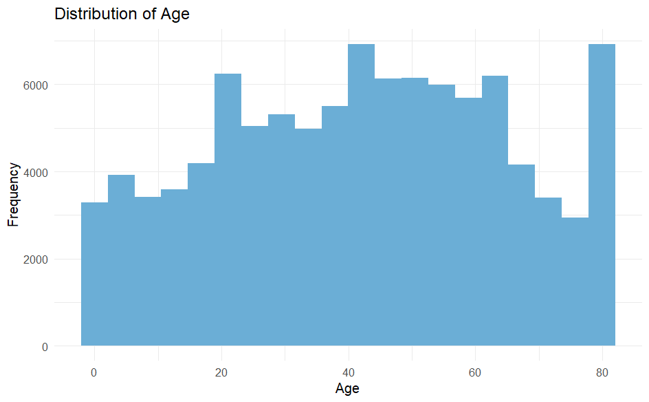

```r
age_hist <- ggplot(diabetes.cleaned, aes(x = age)) +
  geom_histogram(bins = 20, fill = "#6baed6") +
  labs(title = "Distribution of Age", x = "Age", y = "Frequency") +
  theme_minimal()
print(age_hist)
```

Interpretation: Among all the age groups in the data, geriatrics individuals aged 40 years, 80 years are higher.

2. Bar graph for gender

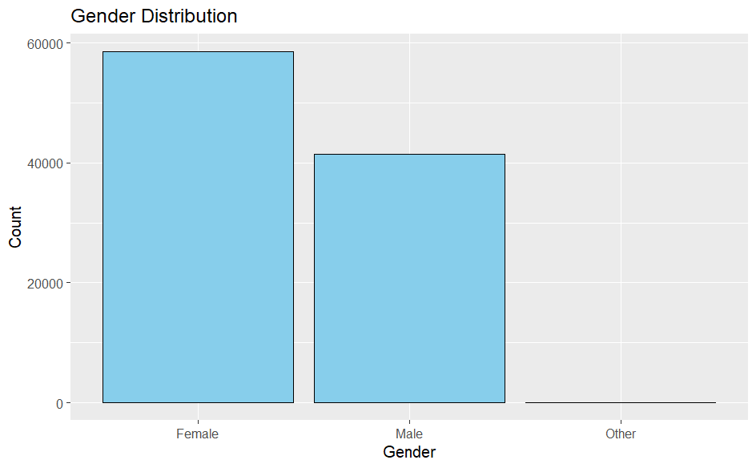

```r
# Assuming your dataframe is named "diabetes.cleaned"
ggplot(diabetes.cleaned, aes(x = gender)) +
  geom_bar(fill = "skyblue", color = "black") +
  labs(title = "Gender Distribution", x = "Gender", y = "Count")
```

Interpretation: In the data, females are higher than males followed by others.

3.Scatter plot for age and Hba1c level comparision

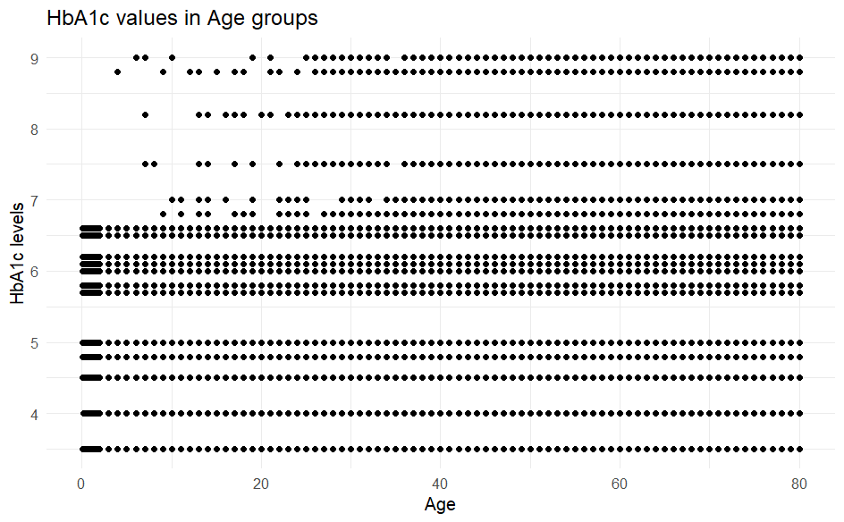

```r
scatter.age.HbA1c <- diabetes.cleaned %>%
ggplot(aes(x = age, y = HbA1c_level)) +
geom_point() +
theme_minimal() +
labs(title="HbA1c values in Age groups", x= "Age", y = "HbA1c levels")
scatter.age.HbA1c
```

4.Bar Graph for Diabetes Prevalence

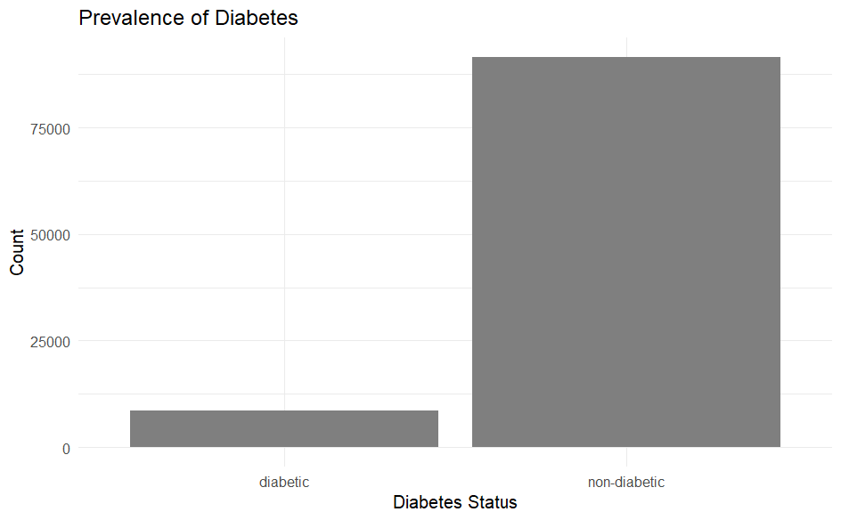

```r
diabetes_bar <- ggplot(diabetes.cleaned, aes(x = factor(diabetes), fill = factor(diabetes))) +
  geom_bar() +
  scale_fill_manual(values = c("0" = "#1f77b4", "1" = "#ff7f0e"), labels = c("No (0)", "Yes (1)")) +
  labs(title = "Prevalence of Diabetes", x = "Diabetes Status", y = "Count") +
  theme_minimal()
print(diabetes_bar)
```

Interpretation: Among all the individuals non-diabetic individuals are higher than diabetic individuals.

5.Scatter plot for Blood glucose level and Hba1c level comparision

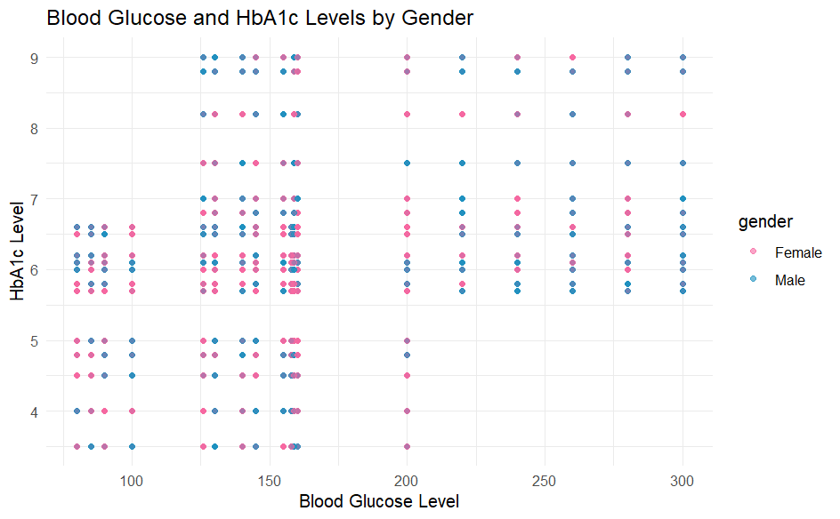

```r
bg_hba1c_point <- ggplot(diabetes.cleaned, aes(x = blood_glucose_level, y = HbA1c_level, color = gender)) +
  geom_point(alpha = 0.6) +
  scale_color_manual(values = c("Female" = "#f768a1", "Male" = "#1d91c0")) +
  labs(title = "Blood Glucose and HbA1c Levels by Gender", x = "Blood Glucose Level", y = "HbA1c Level") +
  theme_minimal()
print(bg_hba1c_point)
```

Interpretation: People having higher blood glucose levels have higher HbA1c values in both genders(male and females).

#Data management

```r
# Function to remove outliers based on IQR
remove_outliers <- function(data, column) {
  Q1 <- quantile(data[[column]], 0.25)
  Q3 <- quantile(data[[column]], 0.75)
  IQR <- Q3 - Q1
  lower_bound <- Q1 - 1.5 * IQR
  upper_bound <- Q3 + 1.5 * IQR
  data[data[[column]] >= lower_bound & data[[column]] <= upper_bound, ]
}


# Applying outlier removal for BMI
diabetes.cleaned.final <- remove_outliers(diabetes.cleaned, "bmi")

# Applying outlier removal for HbA1c Level
diabetes.cleaned.final <- remove_outliers(diabetes.cleaned, "HbA1c_level")

# Applying outlier removal for Blood Glucose Level
diabetes.cleaned.final <- remove_outliers(diabetes.cleaned, "blood_glucose_level")
```

```r
summary(diabetes.cleaned.final)
```

```
    gender           age                  hypertension            heart_disease
 Female:57478   Min.   : 0.08   hypertensive    : 6991   Heart disease   : 3634
 Male  :40466   1st Qu.:23.00   non-hypertensive:90971   No heart disease:94328
 Other :   18   Median :42.00
                Mean   :41.49
                3rd Qu.:59.00
                Max.   :80.00
    smoking_history       bmi         HbA1c_level    blood_glucose_level         diabetes
 current    : 9037   Min.   :10.01   Min.   :3.500   Min.   : 80.0       diabetic    : 6462
 ever       : 3904   1st Qu.:23.54   1st Qu.:4.800   1st Qu.:100.0       non-diabetic:91500
 former     : 8981   Median :27.32   Median :5.800   Median :140.0
 never      :34326   Mean   :27.22   Mean   :5.499   Mean   :135.1
 No Info    :35450   3rd Qu.:29.40   3rd Qu.:6.200   3rd Qu.:158.0
 not current: 6264   Max.   :95.69   Max.   :9.000   Max.   :240.0
```

##Statistical Analysis and Assumptions: CHI SQUARE TEST: As the dependent variable (diabetes) is a binary variable the appropriate test performed is Chi-square test.It is done for two categorical variables.

1. For diabetes and gender Null Hypothesis (H0): There is no association between diabetes and gender. Alternate Hypothesis (H1): There is an association between diabetes and gender.

```r
chisq.test(x = diabetes.cleaned$diabetes, y = diabetes.cleaned$gender)
```

```
    Pearson's Chi-squared test

data:  diabetes.cleaned$diabetes and diabetes.cleaned$gender
X-squared = 143.22, df = 2, p-value < 2.2e-16
```

The test statistic is χ2 : 143.22 p < 0.05 = Rejecting Null Hypothesis Interpretation: Chi-squared test is used to test the null hypothesis. There was relationship between on diabetes and gender. We rejected the null hypothesis and concluded that there was a relationship between diabetes and gender. [χ2 = 143.22; p < 0.05].

2. For diabetes and smoking history Null Hypothesis (H0): There is no association between diabetes and smoking history. Alternate Hypothesis (H1): There is an association between diabetes and smoking history.

```r
chisq.test(x = diabetes.cleaned$diabetes, y = diabetes.cleaned$smoking_history)
```

```
    Pearson's Chi-squared test

data:  diabetes.cleaned$diabetes and diabetes.cleaned$smoking_history
X-squared = 1956.1, df = 5, p-value < 2.2e-16
```

The test statistic is χ2 : 1956.1 p < 0.05 = Rejecting Null Hypothesis Interpretation: Chi-squared test is used to test the null hypothesis. There was relationship between on diabetes and smoking history. We rejected the null hypothesis and concluded that there was a relationship between diabetes and smoking history. [χ2 = 1956.1; p < 0.05].

3. For diabetes and heart disease Null Hypothesis (H0): There is no association between diabetes and heart disease. Alternate Hypothesis (H1): There is an association between diabetes and heart disease.

```r
chisq.test(x = diabetes.cleaned$diabetes, y = diabetes.cleaned$heart_disease)
```

```
    Pearson's Chi-squared test with Yates' continuity correction

data:  diabetes.cleaned$diabetes and diabetes.cleaned$heart_disease
X-squared = 2945.8, df = 1, p-value < 2.2e-16
```

The test statistic is χ2 : 2945.8 p < 0.05 = Rejecting Null Hypothesis Interpretation: Chi-squared test is used to test the null hypothesis. There was relationship between on diabetes and heart disease. We rejected the null hypothesis and concluded that there was a relationship between diabetes and heart disease. [χ2 = 2945.8; p < 0.05].

4. For diabetes and hypertension Null Hypothesis (H0): There is no association between diabetes and hypertension. Alternate Hypothesis (H1): There is an association between diabetes and hypertension.

```r
chisq.test(x = diabetes.cleaned$diabetes, y = diabetes.cleaned$hypertension)
```

```
    Pearson's Chi-squared test with Yates' continuity correction

data:  diabetes.cleaned$diabetes and diabetes.cleaned$hypertension
X-squared = 3910.7, df = 1, p-value < 2.2e-16
```

The test statistic is χ2 : 3910.7 p < 0.05 = Rejecting Null Hypothesis Interpretation: Chi-squared test is used to test the null hypothesis. There was relationship between on diabetes and hypertension. We rejected the null hypothesis and concluded that there was a relationship between diabetes and hypertension. [χ2 = 3910.7; p < 0.05].

```r
CrossTable(x = diabetes.cleaned$diabetes,
           y = diabetes.cleaned$smoking_history,
           expected = TRUE,
           prop.c = FALSE,
           prop.t = FALSE,
           prop.chisq = FALSE,
           chisq = TRUE,
           sresid = TRUE)
```

```
   Cell Contents
|-------------------------|
|                       N |
|              Expected N |
|           N / Row Total |
|-------------------------|


Total Observations in Table:  100000


                          | diabetes.cleaned$smoking_history
diabetes.cleaned$diabetes |     current |        ever |      former |       never |     No Info | not current |   Row Total |
--------------------------|-------------|-------------|-------------|-------------|-------------|-------------|-------------|
                 diabetic |         948 |         472 |        1590 |        3346 |        1454 |         690 |        8500 |
                          |     789.310 |     340.340 |     794.920 |    2983.075 |    3044.360 |     547.995 |             |
                          |       0.112 |       0.056 |       0.187 |       0.394 |       0.171 |       0.081 |       0.085 |
--------------------------|-------------|-------------|-------------|-------------|-------------|-------------|-------------|
             non-diabetic |        8338 |        3532 |        7762 |       31749 |       34362 |        5757 |       91500 |
                          |    8496.690 |    3663.660 |    8557.080 |   32111.925 |   32771.640 |    5899.005 |             |
                          |       0.091 |       0.039 |       0.085 |       0.347 |       0.376 |       0.063 |       0.915 |
--------------------------|-------------|-------------|-------------|-------------|-------------|-------------|-------------|
             Column Total |        9286 |        4004 |        9352 |       35095 |       35816 |        6447 |      100000 |
--------------------------|-------------|-------------|-------------|-------------|-------------|-------------|-------------|


Statistics for All Table Factors


Pearson's Chi-squared test
------------------------------------------------------------
Chi^2 =  1956.094     d.f. =  5     p =  0
```

```r
CrossTable(x = diabetes.cleaned$diabetes,
           y = diabetes.cleaned$gender,
           expected = TRUE,
           prop.c = FALSE,
           prop.t = FALSE,
           prop.chisq = FALSE,
           chisq = TRUE,
           sresid = TRUE)
```

```
   Cell Contents
|-------------------------|
|                       N |
|              Expected N |
|           N / Row Total |
|-------------------------|


Total Observations in Table:  100000


                          | diabetes.cleaned$gender
diabetes.cleaned$diabetes |    Female |      Male |     Other | Row Total |
--------------------------|-----------|-----------|-----------|-----------|
                 diabetic |      4461 |      4039 |         0 |      8500 |
                          |  4976.920 |  3521.550 |     1.530 |           |
                          |     0.525 |     0.475 |     0.000 |     0.085 |
--------------------------|-----------|-----------|-----------|-----------|
             non-diabetic |     54091 |     37391 |        18 |     91500 |
                          | 53575.080 | 37908.450 |    16.470 |           |
                          |     0.591 |     0.409 |     0.000 |     0.915 |
--------------------------|-----------|-----------|-----------|-----------|
             Column Total |     58552 |     41430 |        18 |    100000 |
--------------------------|-----------|-----------|-----------|-----------|


Statistics for All Table Factors


Pearson's Chi-squared test
------------------------------------------------------------
Chi^2 =  143.2183     d.f. =  2     p =  7.953384e-32
```

#Effect size 1. Diabetes, gender

```r
cramersV(x = diabetes.cleaned$diabetes, y = diabetes.cleaned$gender)
```

```
[1] 0.03784419
```

2.For diabetes, smoking history

```r
cramersV(x = diabetes.cleaned$diabetes, y = diabetes.cleaned$smoking_history)
```

```
[1] 0.1398604
```

Interpretation: There is a statistically significant relationship between opinions on diabetes and smoking history, and the relationship is weak or small.

2.For diabetes, smoking heart disease

```r
cramersV(x = diabetes.cleaned$diabetes, y = diabetes.cleaned$heart_disease)
```

```
[1] 0.1716347
```

Interpretation: There is a statistically significant relationship between opinions on diabetes and heart disease, and the relationship is weak or small.

2.For diabetes, hypertension

```r
cramersV(x = diabetes.cleaned$diabetes, y = diabetes.cleaned$hypertension)
```

```
[1] 0.1977551
```

Interpretation: There is a statistically significant relationship between opinions on diabetes and hypertension, and the relationship is weak or small.

#FINAL MODEL-LOGISTIC REGRESSION: For diabetes (Binary variable) Logistic Regression for one variable: Null Hypothesis (H0): Age has no effect on the likelihood of having diabetes. The coefficient for age in the logistic regression model is zero, indicating no relationship between age and the probability of being diagnosed with diabetes. Alternate Hypothesis (H1): Age does affect the likelihood of having diabetes. The coefficient for age in the logistic regression model is not zero, indicating a relationship where the probability of being diagnosed with diabetes changes with age.

```r
logistic_model_age <- glm(diabetes ~ age, family = binomial(), data = diabetes.cleaned)
summary(logistic_model_age)
```

```
Call:
glm(formula = diabetes ~ age, family = binomial(), data = diabetes.cleaned)

Coefficients:
              Estimate Std. Error z value Pr(>|z|)
(Intercept)  4.9368589  0.0411075  120.10   <2e-16 ***
age         -0.0498568  0.0006646  -75.02   <2e-16 ***
---
Signif. codes:  0 ‘***’ 0.001 ‘**’ 0.01 ‘*’ 0.05 ‘.’ 0.1 ‘ ’ 1

(Dispersion parameter for binomial family taken to be 1)

    Null deviance: 58163  on 99999  degrees of freedom
Residual deviance: 50833  on 99998  degrees of freedom
AIC: 50837

Number of Fisher Scoring iterations: 6
```

According to the findings, age is a key predictor of diabetes status, with older people often having a higher chance of receiving a diabetes diagnosis than younger people.

Logistic Regression for multiple variables: Null Hypothesis (H0): Factors like age, gender, hypertension, etc., do not affect diabetes likelihood. Alternate Hypothesis (H1): At least one of the factors affects diabetes likelihood.

```r
logistic_model <- glm(diabetes ~ age + gender + hypertension + heart_disease + smoking_history + bmi + HbA1c_level + blood_glucose_level,
                      family = binomial(), data = diabetes.cleaned)
summary(logistic_model)
```

```
Call:
glm(formula = diabetes ~ age + gender + hypertension + heart_disease +
    smoking_history + bmi + HbA1c_level + blood_glucose_level,
    family = binomial(), data = diabetes.cleaned)

Coefficients:
                                Estimate Std. Error z value Pr(>|z|)
(Intercept)                    2.561e+01  3.008e-01  85.131  < 2e-16 ***
age                           -4.620e-02  1.126e-03 -41.040  < 2e-16 ***
genderMale                    -2.724e-01  3.613e-02  -7.540 4.69e-14 ***
genderOther                    9.475e+00  1.029e+02   0.092  0.92664
hypertensionnon-hypertensive   7.413e-01  4.710e-02  15.737  < 2e-16 ***
heart_diseaseNo heart disease  7.346e-01  6.072e-02  12.099  < 2e-16 ***
smoking_historyever            5.097e-02  9.248e-02   0.551  0.58154
smoking_historyformer          1.084e-01  7.009e-02   1.546  0.12203
smoking_historynever           1.566e-01  6.057e-02   2.586  0.00971 **
smoking_historyNo Info         7.304e-01  6.651e-02  10.981  < 2e-16 ***
smoking_historynot current     2.114e-01  8.332e-02   2.538  0.01115 *
bmi                           -8.895e-02  2.555e-03 -34.819  < 2e-16 ***
HbA1c_level                   -2.340e+00  3.578e-02 -65.413  < 2e-16 ***
blood_glucose_level           -3.336e-02  4.821e-04 -69.207  < 2e-16 ***
---
Signif. codes:  0 ‘***’ 0.001 ‘**’ 0.01 ‘*’ 0.05 ‘.’ 0.1 ‘ ’ 1

(Dispersion parameter for binomial family taken to be 1)

    Null deviance: 58163  on 99999  degrees of freedom
Residual deviance: 22627  on 99986  degrees of freedom
AIC: 22655

Number of Fisher Scoring iterations: 12
```

Logistic regression identified the most potent predictors among demographic, health indicators, and lifestyle factors, providing a comprehensive model of diabetes risk.